# DATA 621 01[46893] : HomeWork1

CUNY_MSDA_ DATA 621_Homework

# 1 Overview

In this homework assignment, you will explore, analyze and model a data set containing approximately 2200 records. Each record represents a professional baseball team from the years 1871 to 2006 inclusive. Each record has the performance of the team for the given year, with all of the statistics adjusted to match the performance of a 162 game season.

We have been given a dataset with 2276 records summarizing a major league baseball team’s season. The records span 1871 to 2006 inclusive. All statistics have been adjusted to match the performance of a 162 game season.

Your objective is to build a multiple linear regression model on the training data to predict the number of wins for the team. You can only use the variables given to you (or variables that you derive from the variables provided).

**Glossary of data**

```r
data.frame(
  `Variable Name` = c("INDEX","TARGET_WINS","TEAM_BATTING_H","TEAM_BATTING_2B","TEAM_BATTING_3B","TEAM_BATTING_HR","TEAM_BATTING_BB","TEAM_BATTING_HBP",
                      "TEAM_BATTING_SO","TEAM_BASERUN_SB","TEAM_BASERUN_CS","TEAM_FIELDING_E","TEAM_FIELDING_DP","TEAM_PITCHING_BB","TEAM_PITCHING_H","TEAM_PITCHING_HR","TEAM_PITCHING_SO"),
  `Definition` = c("Identification Variable (do not use)","Number of wins","Base Hits by batters (1B,2B,3B,HR)","Doubles by batters (2B)","Triples by batters (3B)","Homeruns by batters (4B)","Walks by batters","Batters hit by pitch (get a free base)","Strikeouts by batters","Stolen bases","Caught stealing","Errors","Double Plays","Walks allowed","Hits allowed","Homeruns allowed","Strikeouts by pitchers"),
  `THEORETICAL EFFECT` = c("None","","Positive Impact on Wins","Positive Impact on Wins","Positive Impact on Wins","Positive Impact on Wins","Positive Impact on Wins","Positive Impact on Wins","Negative Impact on Wins","Positive Impact on Wins","Negative Impact on Wins","Negative Impact on Wins","Positive Impact on Wins","Negative Impact on Wins","Negative Impact on Wins","Negative Impact on Wins","Positive Impact on Wins")
) %>%
  kable() %>%
  kable_styling(bootstrap_options = c("striped", "hover", "condensed", "responsive"),full_width = F)
```

Below is a short description of the variables of interest in the data set:

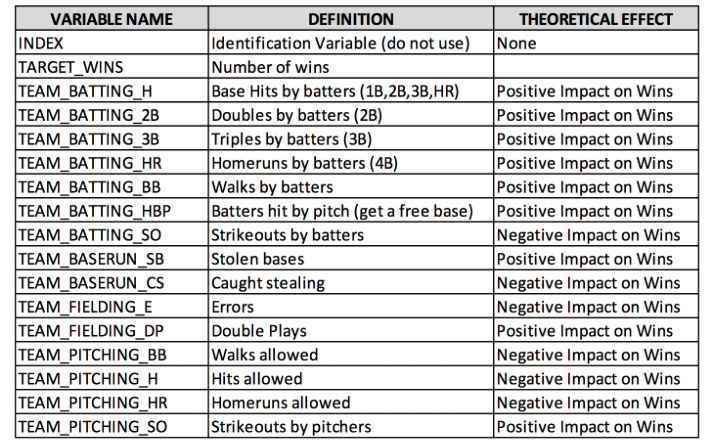

# 2 Deliverables

- A write-up submitted in PDF format. Your write-up should have four sections. Each one is described below. You may assume you are addressing me as a fellow data scientist, so do not need to shy away from technical details.
- Assigned predictions (the number of wins for the team) for the evaluation data set.
- Include your R statistical programming code in an Appendix.

# 3 DATA EXPLORATION

Describe the size and the variables in the moneyball training data set. Consider that too much detail will cause a manager to lose interest while too little detail will make the manager consider that you aren’t doing your job. Some suggestions are given below. Please do NOT treat this as a check list of things to do to complete the assignment.

You should have your own thoughts on what to tell the boss. These are just ideas. a. Mean / Standard Deviation / Median b. Bar Chart or Box Plot of the data c. Is the data correlated to the target variable (or to other variables?) d. Are any of the variables missing and need to be imputed “fixed”?

The data set describes baseball team statistics for the years 1871 to 2006 inclusive. Each record in the data set represents the performance of the team for the given year adjusted to the current length of the season - 162 games. The data set includes 16 variables and the training set includes 2,276 records.

**Load the data and understand the data by using some stats and plots.**

```r
mtd <- read.csv("https://raw.githubusercontent.com/Rajwantmishra/DATA621_CR4/master/HW1/Deb/moneyball-training-data.csv")
med <- read.csv("https://raw.githubusercontent.com/Rajwantmishra/DATA621_CR4/master/HW1/Deb/moneyball-evaluation-data.csv")
```

**View rows and columns, variable types** Glimpse of the data

```r
glimpse(mtd)
```

```
## Observations: 2,276
## Variables: 17
## $ INDEX            <int> 1, 2, 3, 4, 5, 6, 7, 8, 11, 12, 13, 15, 16, 17, 18...
## $ TARGET_WINS      <int> 39, 70, 86, 70, 82, 75, 80, 85, 86, 76, 78, 68, 72...
## $ TEAM_BATTING_H   <int> 1445, 1339, 1377, 1387, 1297, 1279, 1244, 1273, 13...
## $ TEAM_BATTING_2B  <int> 194, 219, 232, 209, 186, 200, 179, 171, 197, 213, ...
## $ TEAM_BATTING_3B  <int> 39, 22, 35, 38, 27, 36, 54, 37, 40, 18, 27, 31, 41...
## $ TEAM_BATTING_HR  <int> 13, 190, 137, 96, 102, 92, 122, 115, 114, 96, 82, ...
## $ TEAM_BATTING_BB  <int> 143, 685, 602, 451, 472, 443, 525, 456, 447, 441, ...
## $ TEAM_BATTING_SO  <int> 842, 1075, 917, 922, 920, 973, 1062, 1027, 922, 82...
## $ TEAM_BASERUN_SB  <int> NA, 37, 46, 43, 49, 107, 80, 40, 69, 72, 60, 119, ...
## $ TEAM_BASERUN_CS  <int> NA, 28, 27, 30, 39, 59, 54, 36, 27, 34, 39, 79, 10...
## $ TEAM_BATTING_HBP <int> NA, NA, NA, NA, NA, NA, NA, NA, NA, NA, NA, NA, NA...
## $ TEAM_PITCHING_H  <int> 9364, 1347, 1377, 1396, 1297, 1279, 1244, 1281, 13...
## $ TEAM_PITCHING_HR <int> 84, 191, 137, 97, 102, 92, 122, 116, 114, 96, 86, ...
## $ TEAM_PITCHING_BB <int> 927, 689, 602, 454, 472, 443, 525, 459, 447, 441, ...
## $ TEAM_PITCHING_SO <int> 5456, 1082, 917, 928, 920, 973, 1062, 1033, 922, 8...
## $ TEAM_FIELDING_E  <int> 1011, 193, 175, 164, 138, 123, 136, 112, 127, 131,...
## $ TEAM_FIELDING_DP <int> NA, 155, 153, 156, 168, 149, 186, 136, 169, 159, 1...
```

```r
head(mtd)
```

|  | INDEX | TARGET_WINS | TEAM_BATTING_H | TEAM_BATTING_2B | TEAM_BATTING_3B | TEAM_BATTING_HR | TEAM_BATTING_BB | TEAM_BATTING_SO | TEAM_BASERUN_SB | TEAM_BASERUN_CS | TEAM_BATTING_HBP | TEAM_PITCHING_H | TEAM_PITCHING_HR | TEAM_PITCHING_BB | TEAM_PITCHING_SO | TEAM_FIELDING_E | TEAM_FIELDING_DP |
| --- | --- | --- | --- | --- | --- | --- | --- | --- | --- | --- | --- | --- | --- | --- | --- | --- | --- |
| 1 | 1 | 39 | 1445 | 194 | 39 | 13 | 143 | 842 | NA | NA | NA | 9364 | 84 | 927 | 5456 | 1011 | NA |
| 2 | 2 | 70 | 1339 | 219 | 22 | 190 | 685 | 1075 | 37 | 28 | NA | 1347 | 191 | 689 | 1082 | 193 | 155 |
| 3 | 3 | 86 | 1377 | 232 | 35 | 137 | 602 | 917 | 46 | 27 | NA | 1377 | 137 | 602 | 917 | 175 | 153 |
| 4 | 4 | 70 | 1387 | 209 | 38 | 96 | 451 | 922 | 43 | 30 | NA | 1396 | 97 | 454 | 928 | 164 | 156 |
| 5 | 5 | 82 | 1297 | 186 | 27 | 102 | 472 | 920 | 49 | 39 | NA | 1297 | 102 | 472 | 920 | 138 | 168 |
| 6 | 6 | 75 | 1279 | 200 | 36 | 92 | 443 | 973 | 107 | 59 | NA | 1279 | 92 | 443 | 973 | 123 | 149 |

Entire dataset

```r
DT::datatable(mtd, options = list(pagelength=5))
```

[output not shown]

[output cut: 2266 more lines]

```r
#DT::datatable(med, options = list(pagelength=5))
```

**Structure of data**

```r
paste("Dimension of dataset", dim(mtd))
```

```
## [1] "Dimension of dataset 2276" "Dimension of dataset 17"
```

```r
paste("Count of dataset", count(mtd))
```

```
## [1] "Count of dataset 2276"
```

```r
summary(mtd)
```

```
##      INDEX         TARGET_WINS     TEAM_BATTING_H TEAM_BATTING_2B
##  Min.   :   1.0   Min.   :  0.00   Min.   : 891   Min.   : 69.0
##  1st Qu.: 630.8   1st Qu.: 71.00   1st Qu.:1383   1st Qu.:208.0
##  Median :1270.5   Median : 82.00   Median :1454   Median :238.0
##  Mean   :1268.5   Mean   : 80.79   Mean   :1469   Mean   :241.2
##  3rd Qu.:1915.5   3rd Qu.: 92.00   3rd Qu.:1537   3rd Qu.:273.0
##  Max.   :2535.0   Max.   :146.00   Max.   :2554   Max.   :458.0
##
##  TEAM_BATTING_3B  TEAM_BATTING_HR  TEAM_BATTING_BB TEAM_BATTING_SO
##  Min.   :  0.00   Min.   :  0.00   Min.   :  0.0   Min.   :   0.0
##  1st Qu.: 34.00   1st Qu.: 42.00   1st Qu.:451.0   1st Qu.: 548.0
##  Median : 47.00   Median :102.00   Median :512.0   Median : 750.0
##  Mean   : 55.25   Mean   : 99.61   Mean   :501.6   Mean   : 735.6
##  3rd Qu.: 72.00   3rd Qu.:147.00   3rd Qu.:580.0   3rd Qu.: 930.0
##  Max.   :223.00   Max.   :264.00   Max.   :878.0   Max.   :1399.0
##                                                    NA's   :102
##  TEAM_BASERUN_SB TEAM_BASERUN_CS TEAM_BATTING_HBP TEAM_PITCHING_H
##  Min.   :  0.0   Min.   :  0.0   Min.   :29.00    Min.   : 1137
##  1st Qu.: 66.0   1st Qu.: 38.0   1st Qu.:50.50    1st Qu.: 1419
##  Median :101.0   Median : 49.0   Median :58.00    Median : 1518
##  Mean   :124.8   Mean   : 52.8   Mean   :59.36    Mean   : 1779
##  3rd Qu.:156.0   3rd Qu.: 62.0   3rd Qu.:67.00    3rd Qu.: 1682
##  Max.   :697.0   Max.   :201.0   Max.   :95.00    Max.   :30132
##  NA's   :131     NA's   :772     NA's   :2085
##  TEAM_PITCHING_HR TEAM_PITCHING_BB TEAM_PITCHING_SO  TEAM_FIELDING_E
##  Min.   :  0.0    Min.   :   0.0   Min.   :    0.0   Min.   :  65.0
##  1st Qu.: 50.0    1st Qu.: 476.0   1st Qu.:  615.0   1st Qu.: 127.0
##  Median :107.0    Median : 536.5   Median :  813.5   Median : 159.0
##  Mean   :105.7    Mean   : 553.0   Mean   :  817.7   Mean   : 246.5
##  3rd Qu.:150.0    3rd Qu.: 611.0   3rd Qu.:  968.0   3rd Qu.: 249.2
##  Max.   :343.0    Max.   :3645.0   Max.   :19278.0   Max.   :1898.0
##                                    NA's   :102
##  TEAM_FIELDING_DP
##  Min.   : 52.0
##  1st Qu.:131.0
##  Median :149.0
##  Mean   :146.4
##  3rd Qu.:164.0
##  Max.   :228.0
##  NA's   :286
```

```r
describe(mtd)
```

```
## mtd
##
##  17  Variables      2276  Observations
## --------------------------------------------------------------------------------
## INDEX
##        n  missing distinct     Info     Mean      Gmd      .05      .10
##     2276        0     2276        1     1268    850.4    125.8    252.5
##      .25      .50      .75      .90      .95
##    630.8   1270.5   1915.5   2287.5   2407.2
##
## lowest :    1    2    3    4    5, highest: 2531 2532 2533 2534 2535
## --------------------------------------------------------------------------------
## TARGET_WINS
##        n  missing distinct     Info     Mean      Gmd      .05      .10
##     2276        0      108        1    80.79    17.47     54.0     61.0
##      .25      .50      .75      .90      .95
##     71.0     82.0     92.0     99.5    104.0
##
## lowest :   0  12  14  17  21, highest: 128 129 134 135 146
## --------------------------------------------------------------------------------
## TEAM_BATTING_H
##        n  missing distinct     Info     Mean      Gmd      .05      .10
##     2276        0      569        1     1469    149.8     1282     1315
##      .25      .50      .75      .90      .95
##     1383     1454     1537     1636     1695
##
## lowest :  891  992 1009 1116 1122, highest: 2333 2343 2372 2496 2554
## --------------------------------------------------------------------------------
## TEAM_BATTING_2B
##        n  missing distinct     Info     Mean      Gmd      .05      .10
##     2276        0      240        1    241.2    52.89      167      182
##      .25      .50      .75      .90      .95
##      208      238      273      303      320
##
## lowest :  69 112 113 118 123, highest: 382 392 393 403 458
## --------------------------------------------------------------------------------
## TEAM_BATTING_3B
##        n  missing distinct     Info     Mean      Gmd      .05      .10
##     2276        0      144        1    55.25    30.34       23       27
##      .25      .50      .75      .90      .95
```

[output cut: 95 more lines]

```
##        n  missing distinct     Info     Mean      Gmd      .05      .10
##     2276        0      549        1    246.5    190.4    100.0    109.0
##      .25      .50      .75      .90      .95
##    127.0    159.0    249.2    542.0    716.0
##
## lowest :   65   66   68   72   74, highest: 1567 1728 1740 1890 1898
## --------------------------------------------------------------------------------
## TEAM_FIELDING_DP
##        n  missing distinct     Info     Mean      Gmd      .05      .10
##     1990      286      144        1    146.4    29.29       98      109
##      .25      .50      .75      .90      .95
##      131      149      164      178      186
##
## lowest :  52  64  68  71  72, highest: 215 218 219 225 228
## --------------------------------------------------------------------------------
```

```r
names(mtd)
```

```
##  [1] "INDEX"            "TARGET_WINS"      "TEAM_BATTING_H"   "TEAM_BATTING_2B"
##  [5] "TEAM_BATTING_3B"  "TEAM_BATTING_HR"  "TEAM_BATTING_BB"  "TEAM_BATTING_SO"
##  [9] "TEAM_BASERUN_SB"  "TEAM_BASERUN_CS"  "TEAM_BATTING_HBP" "TEAM_PITCHING_H"
## [13] "TEAM_PITCHING_HR" "TEAM_PITCHING_BB" "TEAM_PITCHING_SO" "TEAM_FIELDING_E"
## [17] "TEAM_FIELDING_DP"
```

```r
str(mtd)
```

```
## 'data.frame':    2276 obs. of  17 variables:
##  $ INDEX           : int  1 2 3 4 5 6 7 8 11 12 ...
##  $ TARGET_WINS     : int  39 70 86 70 82 75 80 85 86 76 ...
##  $ TEAM_BATTING_H  : int  1445 1339 1377 1387 1297 1279 1244 1273 1391 1271 ...
##  $ TEAM_BATTING_2B : int  194 219 232 209 186 200 179 171 197 213 ...
##  $ TEAM_BATTING_3B : int  39 22 35 38 27 36 54 37 40 18 ...
##  $ TEAM_BATTING_HR : int  13 190 137 96 102 92 122 115 114 96 ...
##  $ TEAM_BATTING_BB : int  143 685 602 451 472 443 525 456 447 441 ...
##  $ TEAM_BATTING_SO : int  842 1075 917 922 920 973 1062 1027 922 827 ...
##  $ TEAM_BASERUN_SB : int  NA 37 46 43 49 107 80 40 69 72 ...
##  $ TEAM_BASERUN_CS : int  NA 28 27 30 39 59 54 36 27 34 ...
##  $ TEAM_BATTING_HBP: int  NA NA NA NA NA NA NA NA NA NA ...
##  $ TEAM_PITCHING_H : int  9364 1347 1377 1396 1297 1279 1244 1281 1391 1271 ...
##  $ TEAM_PITCHING_HR: int  84 191 137 97 102 92 122 116 114 96 ...
##  $ TEAM_PITCHING_BB: int  927 689 602 454 472 443 525 459 447 441 ...
##  $ TEAM_PITCHING_SO: int  5456 1082 917 928 920 973 1062 1033 922 827 ...
##  $ TEAM_FIELDING_E : int  1011 193 175 164 138 123 136 112 127 131 ...
##  $ TEAM_FIELDING_DP: int  NA 155 153 156 168 149 186 136 169 159 ...
```

```r
mtd %>%
  summary() %>%
  kable() %>%
  kable_styling()
```

|  | INDEX | TARGET_WINS | TEAM_BATTING_H | TEAM_BATTING_2B | TEAM_BATTING_3B | TEAM_BATTING_HR | TEAM_BATTING_BB | TEAM_BATTING_SO | TEAM_BASERUN_SB | TEAM_BASERUN_CS | TEAM_BATTING_HBP | TEAM_PITCHING_H | TEAM_PITCHING_HR | TEAM_PITCHING_BB | TEAM_PITCHING_SO | TEAM_FIELDING_E | TEAM_FIELDING_DP |
| --- | --- | --- | --- | --- | --- | --- | --- | --- | --- | --- | --- | --- | --- | --- | --- | --- | --- |
|  | Min. : 1.0 | Min. : 0.00 | Min. : 891 | Min. : 69.0 | Min. : 0.00 | Min. : 0.00 | Min. : 0.0 | Min. : 0.0 | Min. : 0.0 | Min. : 0.0 | Min. :29.00 | Min. : 1137 | Min. : 0.0 | Min. : 0.0 | Min. : 0.0 | Min. : 65.0 | Min. : 52.0 |
|  | 1st Qu.: 630.8 | 1st Qu.: 71.00 | 1st Qu.:1383 | 1st Qu.:208.0 | 1st Qu.: 34.00 | 1st Qu.: 42.00 | 1st Qu.:451.0 | 1st Qu.: 548.0 | 1st Qu.: 66.0 | 1st Qu.: 38.0 | 1st Qu.:50.50 | 1st Qu.: 1419 | 1st Qu.: 50.0 | 1st Qu.: 476.0 | 1st Qu.: 615.0 | 1st Qu.: 127.0 | 1st Qu.:131.0 |
|  | Median :1270.5 | Median : 82.00 | Median :1454 | Median :238.0 | Median : 47.00 | Median :102.00 | Median :512.0 | Median : 750.0 | Median :101.0 | Median : 49.0 | Median :58.00 | Median : 1518 | Median :107.0 | Median : 536.5 | Median : 813.5 | Median : 159.0 | Median :149.0 |
|  | Mean :1268.5 | Mean : 80.79 | Mean :1469 | Mean :241.2 | Mean : 55.25 | Mean : 99.61 | Mean :501.6 | Mean : 735.6 | Mean :124.8 | Mean : 52.8 | Mean :59.36 | Mean : 1779 | Mean :105.7 | Mean : 553.0 | Mean : 817.7 | Mean : 246.5 | Mean :146.4 |
|  | 3rd Qu.:1915.5 | 3rd Qu.: 92.00 | 3rd Qu.:1537 | 3rd Qu.:273.0 | 3rd Qu.: 72.00 | 3rd Qu.:147.00 | 3rd Qu.:580.0 | 3rd Qu.: 930.0 | 3rd Qu.:156.0 | 3rd Qu.: 62.0 | 3rd Qu.:67.00 | 3rd Qu.: 1682 | 3rd Qu.:150.0 | 3rd Qu.: 611.0 | 3rd Qu.: 968.0 | 3rd Qu.: 249.2 | 3rd Qu.:164.0 |
|  | Max. :2535.0 | Max. :146.00 | Max. :2554 | Max. :458.0 | Max. :223.00 | Max. :264.00 | Max. :878.0 | Max. :1399.0 | Max. :697.0 | Max. :201.0 | Max. :95.00 | Max. :30132 | Max. :343.0 | Max. :3645.0 | Max. :19278.0 | Max. :1898.0 | Max. :228.0 |
|  | NA | NA | NA | NA | NA | NA | NA | NA’s :102 | NA’s :131 | NA’s :772 | NA’s :2085 | NA | NA | NA | NA’s :102 | NA | NA’s :286 |

```r
train <- mtd
test <- med
train$INDEX <- NULL
test$INDEX <- NULL

cleanNames <- function(train) {
    name_list <- names(train)
    name_list <- gsub("TEAM_", "", name_list)
    names(train) <- name_list
    train
}

mtd <- cleanNames(train)
med <- cleanNames(test)
```

**Visualize the data**

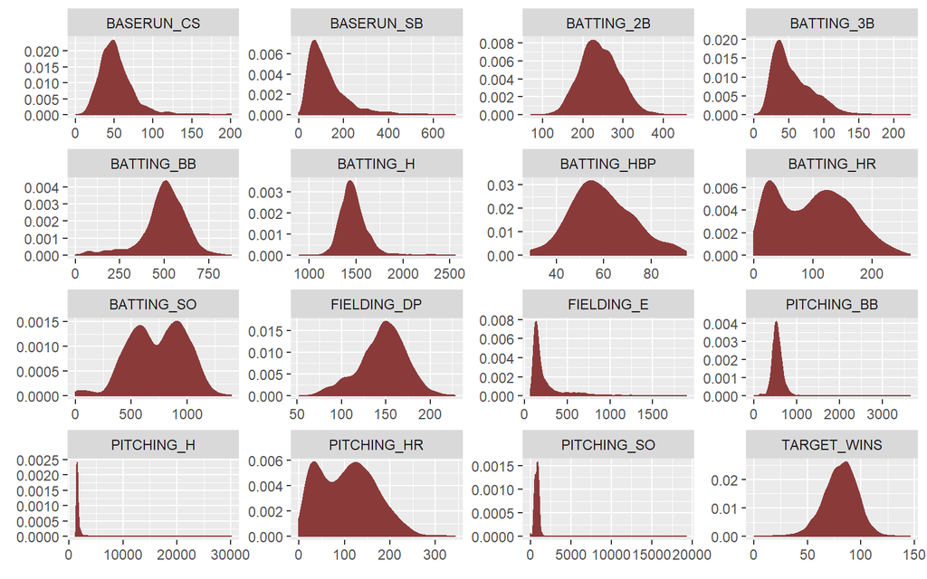

```r
mtd %>%
  gather(variable, value, TARGET_WINS:FIELDING_DP) %>%
  ggplot(., aes(value)) +
  geom_density(fill = "indianred4", color="indianred4") +
  facet_wrap(~variable, scales ="free", ncol = 4) +
  labs(x = element_blank(), y = element_blank())
```

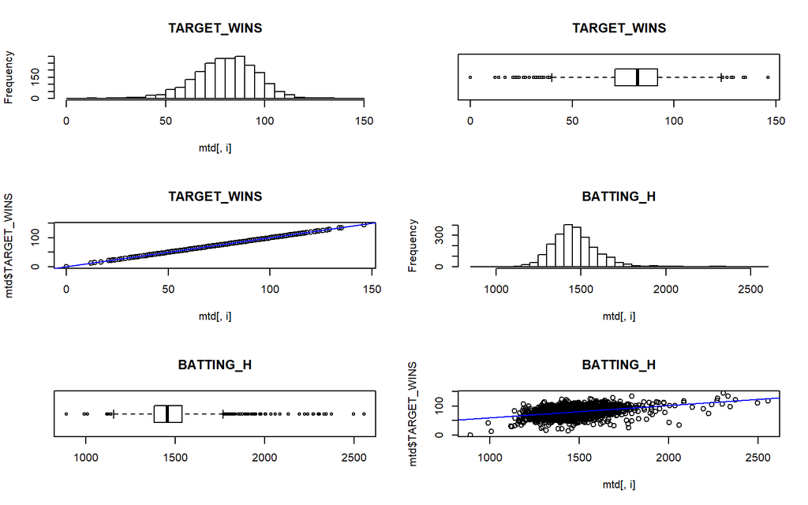

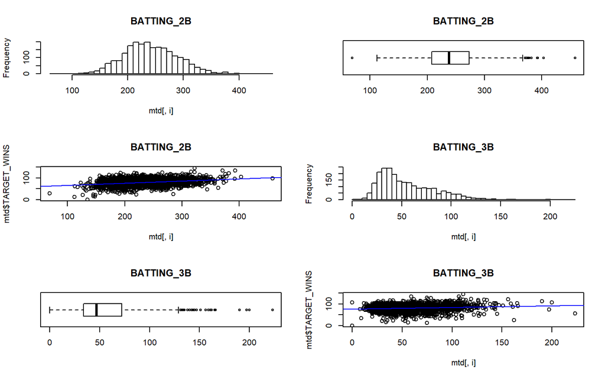

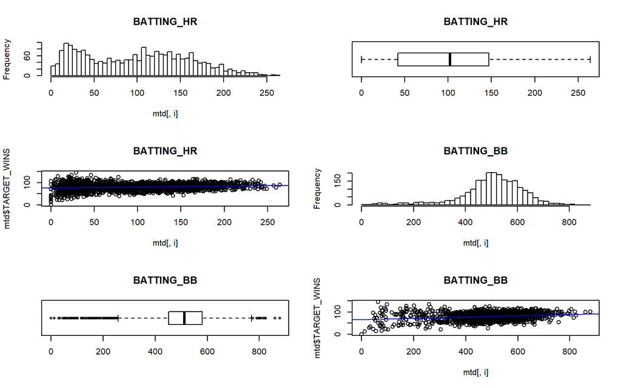

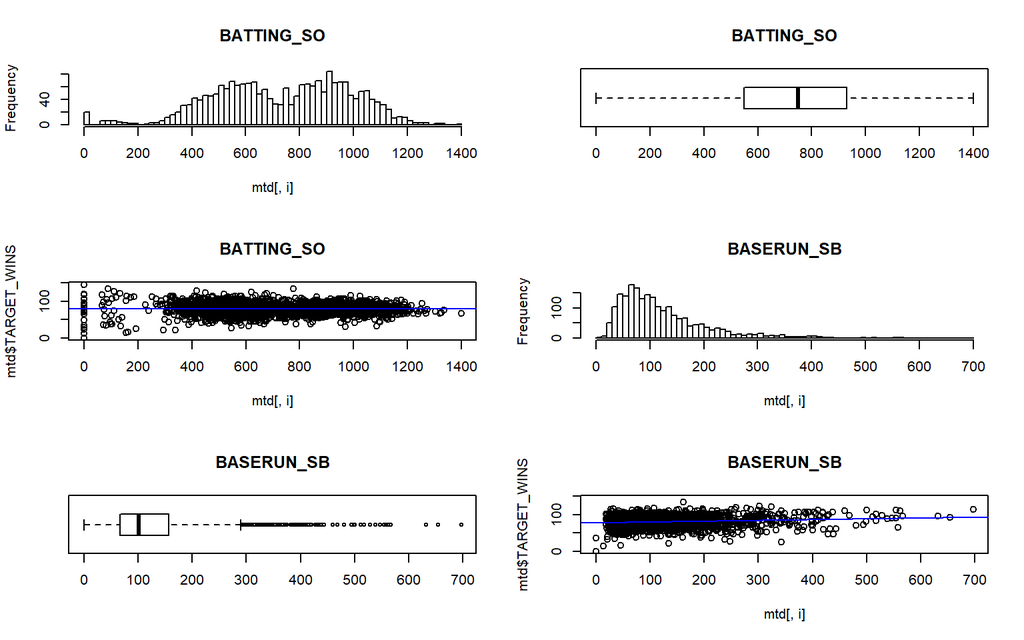

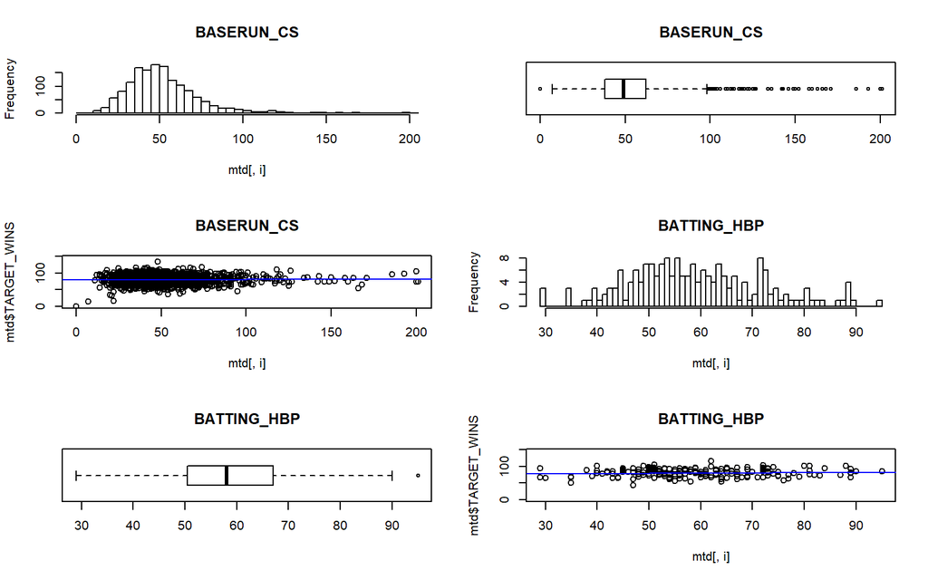

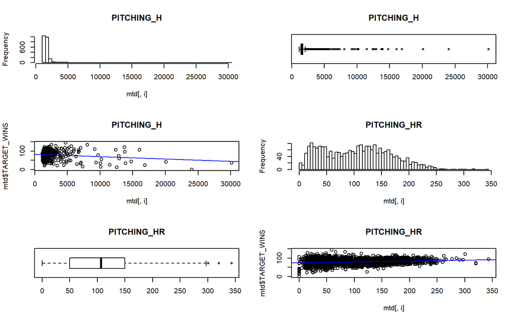

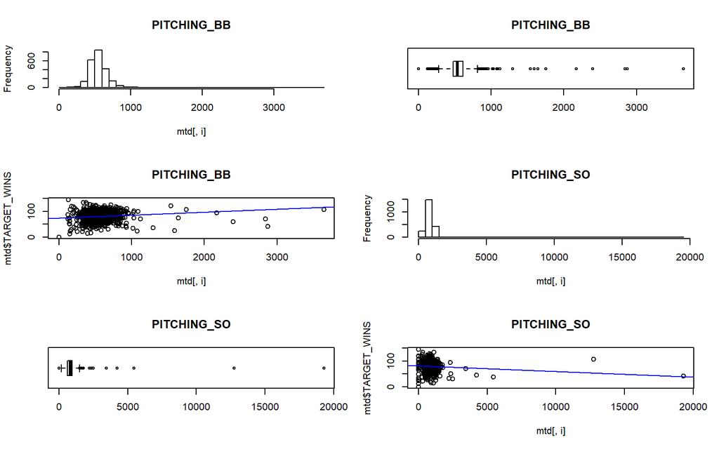

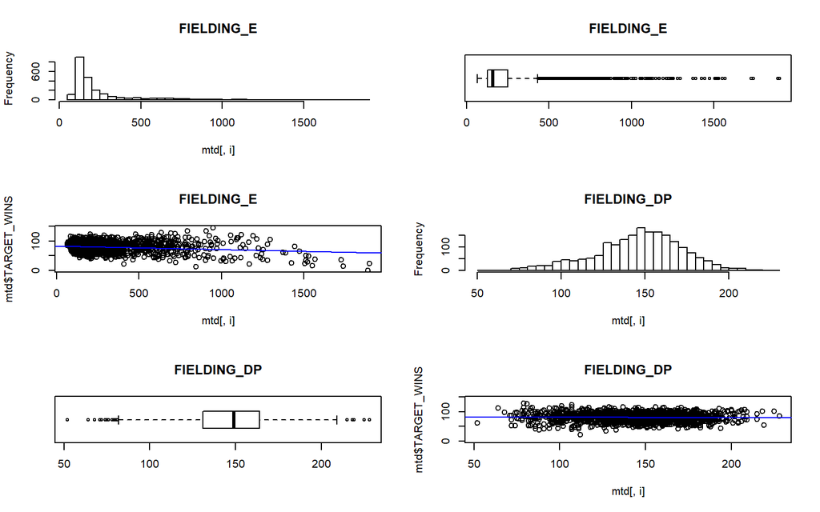

```r
par(mfrow=c(3,2))
for (i in 1:16) {
      hist(mtd[,i],main=names(mtd[i]),51)
      boxplot(mtd[,i], main=names(mtd[i]), type="l",horizontal = TRUE)

      plot(mtd[,i], mtd$TARGET_WINS, main = names(mtd[i]))
      abline(lm(mtd$TARGET_WINS ~ mtd[,i], data = mtd), col = "blue")
}
```

In the histogram plot below, we see that the batting, pitching home-run and batting strike-out variables are bi modal. Also, half of the variables show skewness. We will create a box-cox transformation to build our model to mitigate the skewness.

**Missing Values**

```r
mtd %>%
  gather(variable, value) %>%
  filter(is.na(value)) %>%
  group_by(variable) %>%
  tally() %>%
  mutate(percent = n / nrow(mtd) * 100) %>%
  mutate(percent = paste0(round(percent, ifelse(percent < 10, 1, 0)), "%")) %>%
  arrange(desc(n)) %>%
#  rename(`Variable Missing Data`=variable,`Number of Records`=n,`Share of Total`=percent) %>%
  kable() %>%
  kable_styling()
```

| variable | n | percent |
| --- | --- | --- |
| BATTING_HBP | 2085 | 92% |
| BASERUN_CS | 772 | 34% |
| FIELDING_DP | 286 | 13% |
| BASERUN_SB | 131 | 5.8% |
| BATTING_SO | 102 | 4.5% |
| PITCHING_SO | 102 | 4.5% |

The hit by pitcher varriable is missing over 90% of it’s data.

**Zero Values**

```r
mtd %>%
  gather(variable, value) %>%
  filter(value == 0) %>%
  group_by(variable) %>%
  tally() %>%
  mutate(percent = n / nrow(mtd) * 100) %>%
  mutate(percent = paste0(round(percent, ifelse(percent < 10, 1, 0)), "%")) %>%
  arrange(desc(n)) %>%
#  rename("Variable With Zeros"=variable,"Number of Records"=n,"Share of Total"=percent) %>%
  kable() %>%
  kable_styling()
```

| variable | n | percent |
| --- | --- | --- |
| BATTING_SO | 20 | 0.9% |
| PITCHING_SO | 20 | 0.9% |
| BATTING_HR | 15 | 0.7% |
| PITCHING_HR | 15 | 0.7% |
| BASERUN_SB | 2 | 0.1% |
| BATTING_3B | 2 | 0.1% |
| BASERUN_CS | 1 | 0% |
| BATTING_BB | 1 | 0% |
| PITCHING_BB | 1 | 0% |
| TARGET_WINS | 1 | 0% |

As can be inferred from above, there are Very few zero values exists.

**Checking for outliers**

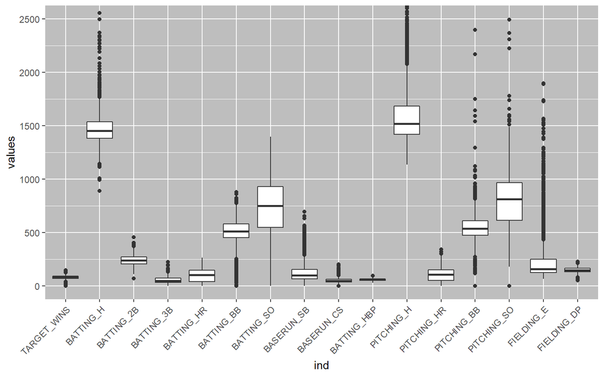

```r
ggplot(stack(mtd), aes(x = ind, y = values)) +
  geom_boxplot() +
  coord_cartesian(ylim = c(0, 2500)) +
  theme(legend.position="none") +
  theme(axis.text.x=element_text(angle=45, hjust=1)) +
  theme(panel.background = element_rect(fill = 'grey'))
```

The box plots reveal that a great majority of the explanatory variables have high variances. Many of the medians and means are also not aligned which demonstrates the outliers’ effects.

The variance of some of the explanatory variables greatly exceeds the variance of the response “win” variable. The dataset has many outlines with some observations that are more extreme than the 1.5 * IQR of the box plot whiskers.

**Checking for skewness in the data**

```
## Using  as id variables
```

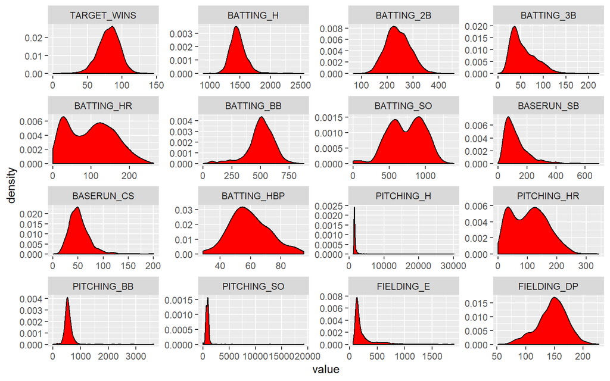

```r
melt(mtd) %>%
  ggplot(aes(x= value)) +
    geom_density(fill='red') + facet_wrap(~variable, scales = 'free')
```

As per above, there are several variables that are skewed and also there are outliers.

**Finding correlations:**

```r
DT::datatable(cor(drop_na(mtd[,])), options = list(pagelength=5))
```

|  | TARGET_WINS | BATTING_H | BATTING_2B | BATTING_3B | BATTING_HR | BATTING_BB | BATTING_SO | BASERUN_SB | BASERUN_CS | BATTING_HBP | PITCHING_H | PITCHING_HR | PITCHING_BB | PITCHING_SO | FIELDING_E | FIELDING_DP |
| --- | --- | --- | --- | --- | --- | --- | --- | --- | --- | --- | --- | --- | --- | --- | --- | --- |
| TARGET_WINS | 1 | 0.469946650195572 | 0.312983997280004 | -0.124345862964454 | 0.422416834117253 | 0.46868792650956 | -0.228892727179823 | 0.014836392442652 | -0.178755979245533 | 0.0735042423086367 | 0.471234306386603 | 0.422466829910362 | 0.468398817921509 | -0.229364807443985 | -0.38668800441918 | -0.195866006470866 |
| BATTING_H | 0.469946650195572 | 1 | 0.561772855536591 | 0.213918834444827 | 0.396275927326416 | 0.197352343885384 | -0.341743283600818 | 0.0716749520962244 | -0.093775445091233 | -0.029112175684042 | 0.99919269234311 | 0.394956298700172 | 0.195290710544474 | -0.344450005208324 | -0.253816375660435 | 0.0177694564092798 |
| BATTING_2B | 0.312983997280004 | 0.561772855536591 | 1 | 0.0420344070268067 | 0.250990454027817 | 0.197492562030794 | -0.0641512258250527 | -0.187682787958738 | -0.204138837073558 | 0.046084753143314 | 0.56045354847602 | 0.249998747553797 | 0.195921565513306 | -0.0661661537512398 | -0.194270273091531 | -0.0248880814856196 |
| BATTING_3B | -0.124345862964454 | 0.213918834444827 | 0.0420344070268067 | 1 | -0.21879927259709 | -0.205843921730807 | -0.192918409979567 | 0.169460861525657 | 0.232139777238505 | -0.174247153838812 | 0.212503220228309 | -0.219732634585348 | -0.206753828035744 | -0.193866539346945 | -0.0651314505185477 | 0.133147578454026 |
| BATTING_HR | 0.422416834117253 | 0.396275927326416 | 0.250990454027817 | -0.21879927259709 | 1 | 0.45638161304111 | 0.210454439156417 | -0.190218931518434 | -0.275798375425212 | 0.10618116006506 | 0.395493896422292 | 0.999932586464182 | 0.455424675903605 | 0.208295737583337 | 0.0156739746858487 | -0.0618222186945481 |
| BATTING_BB | 0.46868792650956 | 0.197352343885384 | 0.197492562030794 | -0.205843921730807 | 0.45638161304111 | 1 | 0.218338710909898 | -0.0880612337283994 | -0.208780509828045 | 0.0474600667564786 | 0.19848686711087 | 0.456592825864783 | 0.999881395126833 | 0.217932529917855 | -0.0784712614857361 | -0.0792907752389707 |
| BATTING_SO | -0.228892727179823 | -0.341743283600818 | -0.0641512258250527 | -0.192918409979567 | 0.210454439156417 | 0.218338710909898 | 1 | -0.0747597360691117 | -0.0561303548530689 | 0.220942194261665 | -0.341453205593245 | 0.211116173816555 | 0.218957832493308 | 0.999768352626016 | 0.30814540314676 | -0.123190715333224 |
| BASERUN_SB | 0.014836392442652 | 0.0716749520962244 | -0.187682787958738 | 0.169460861525657 | -0.190218931518434 | -0.0880612337283994 | -0.0747597360691117 | 1 | 0.624737807561251 | -0.064004981618153 | 0.0739537311509114 | -0.189480573217968 | -0.0874190190869081 | -0.0735132452545342 | 0.0429234095279743 | -0.130230537221142 |
| BASERUN_CS | -0.178755979245533 | -0.093775445091233 | -0.204138837073558 | 0.232139777238505 | -0.275798375425212 | -0.208780509828045 | -0.0561303548530689 | 0.624737807561251 | 1 | -0.0705138957544245 | -0.0929778928838545 | -0.275471495304311 | -0.208470153567062 | -0.0553083364439619 | 0.207701188904909 | -0.0067642330423307 |
| BATTING_HBP | 0.0735042423086367 | -0.029112175684042 | 0.046084753143314 | -0.174247153838812 | 0.10618116006506 | 0.0474600667564786 | 0.220942194261665 | -0.064004981618153 | -0.0705138957544245 | 1 | -0.0276969948986031 | 0.106758779766898 | 0.0478513710439057 | 0.221573754128533 | 0.0417897122711344 | -0.0712082411629195 |

[output cut: 6 more lines]

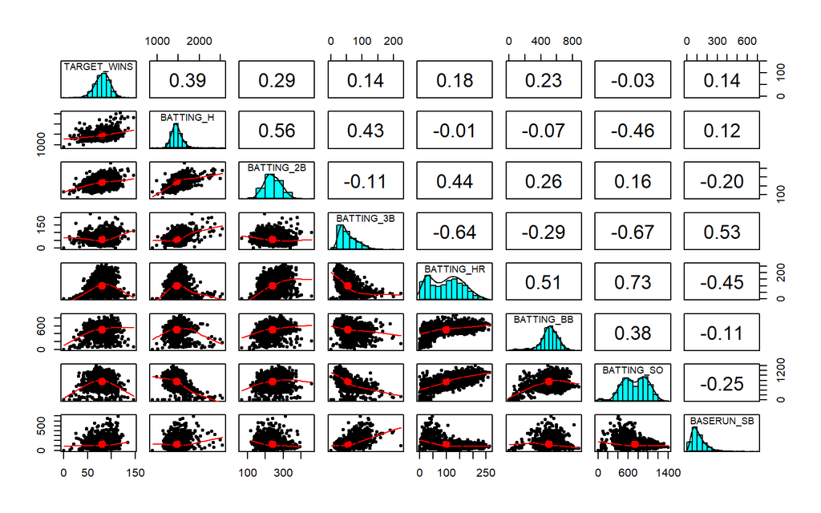

```r
pairs.panels((mtd[,])[1:8])
```

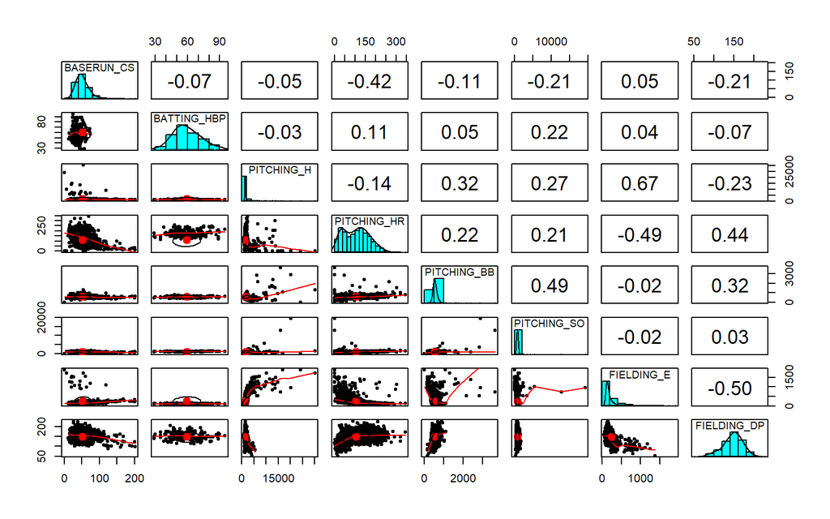

```r
pairs.panels((mtd[,])[9:16])
```

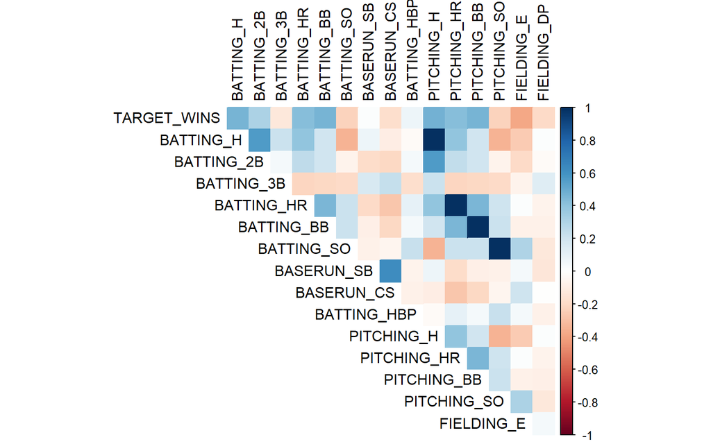

```r
mtd %>%
  cor(., use = "complete.obs") %>%
  corrplot(., method = "color", type = "upper", tl.col = "black", diag = FALSE)
```

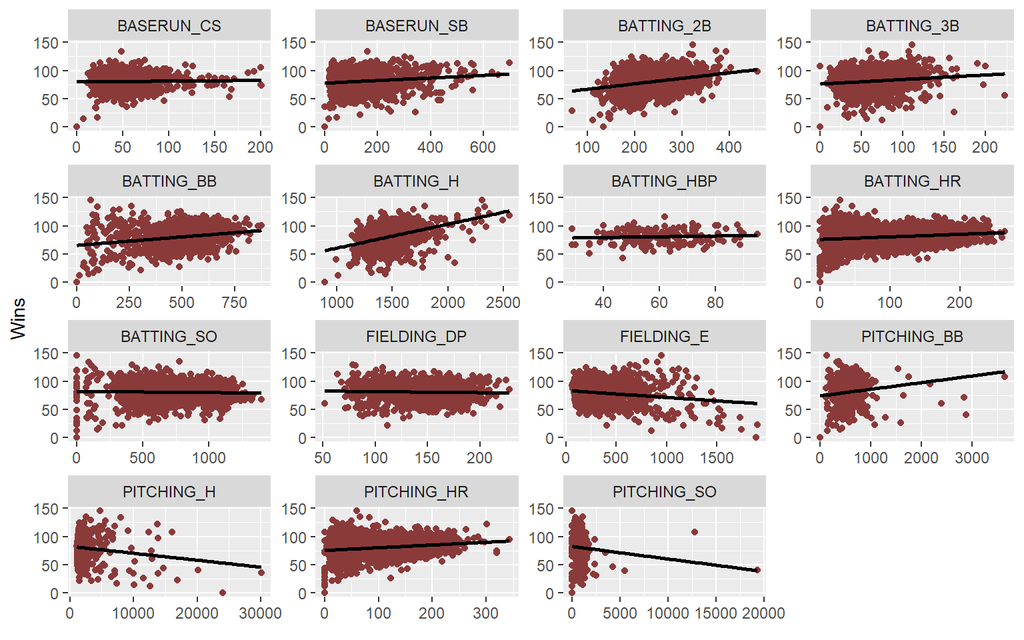

```r
mtd %>%
  gather(variable, value, -TARGET_WINS) %>%
  ggplot(., aes(value, TARGET_WINS)) +
  geom_point(fill = "indianred4", color="indianred4") +
  geom_smooth(method = "lm", se = FALSE, color = "black") +
  facet_wrap(~variable, scales ="free", ncol = 4) +
  labs(x = element_blank(), y = "Wins")
```

Also, there are some negatively correlated variables. According to the correlation heatmap, the values that correspond most positively are BATTING_H, BATTING_2B, BATTING_HR, BATTING_BB, PITCHING_H, PITCHING_HR, and PITCHING_BB.

**Histogram of Variables**

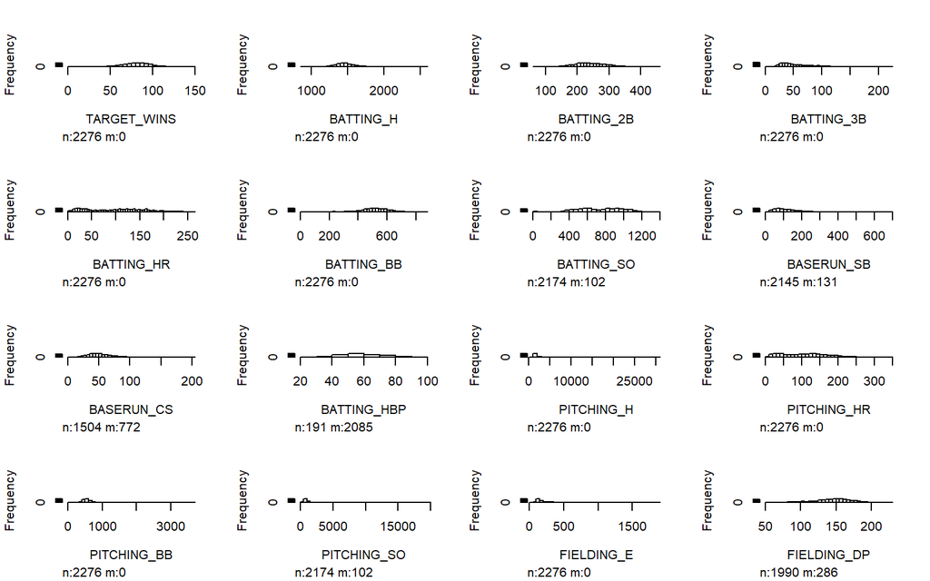

```r
hist.data.frame(mtd)
```

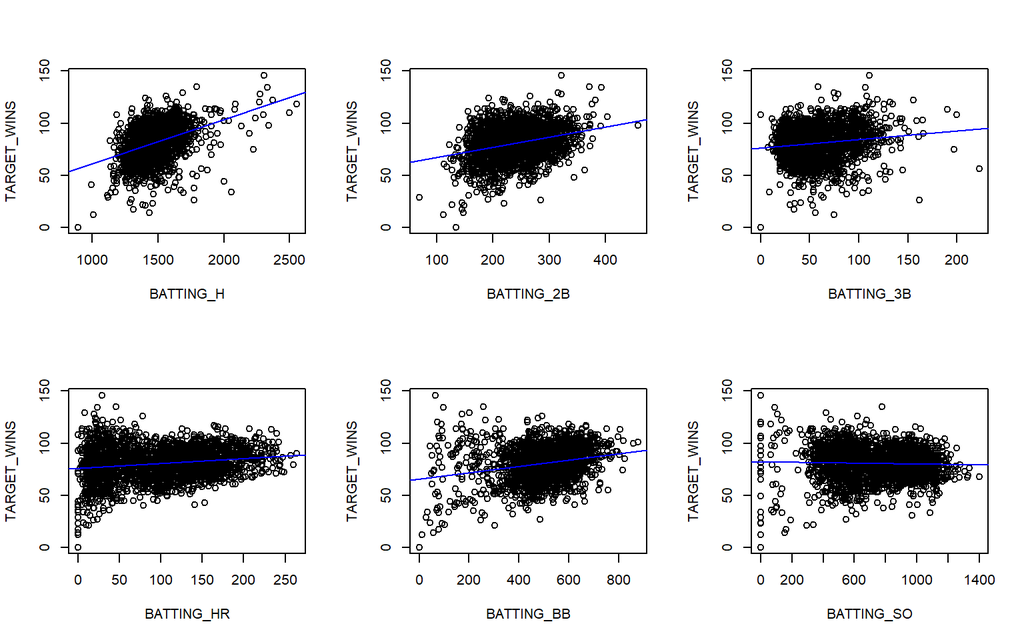

```r
par(mfrow=c(2,3))
plot(TARGET_WINS ~ BATTING_H,mtd)
  abline(lm(TARGET_WINS ~ BATTING_H,data = mtd),col="blue")
plot(TARGET_WINS ~ BATTING_2B,mtd)
  abline(lm(TARGET_WINS ~ BATTING_2B,data = mtd),col="blue")
plot(TARGET_WINS ~ BATTING_3B,mtd)
  abline(lm(TARGET_WINS ~ BATTING_3B,data = mtd),col="blue")
plot(TARGET_WINS ~ BATTING_HR,mtd)
  abline(lm(TARGET_WINS ~ BATTING_HR,data = mtd),col="blue")
plot(TARGET_WINS ~ BATTING_BB,mtd)
  abline(lm(TARGET_WINS ~ BATTING_BB,data = mtd),col="blue")
plot(TARGET_WINS ~ BATTING_SO,mtd)
  abline(lm(TARGET_WINS ~ BATTING_SO,data = mtd),col="blue")
```

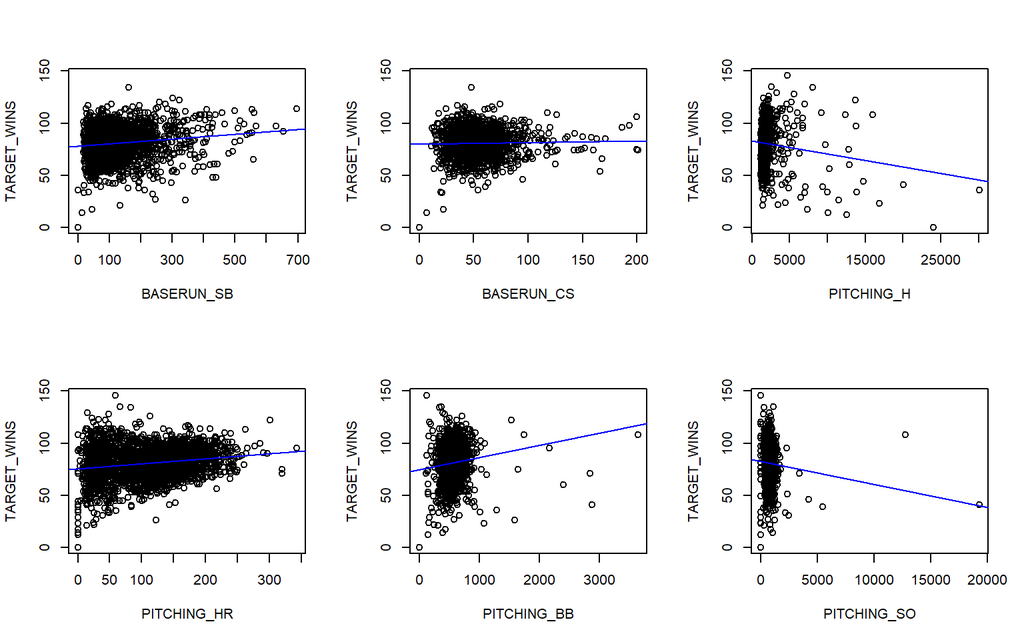

```r
plot(TARGET_WINS ~ BASERUN_SB,mtd)
  abline(lm(TARGET_WINS ~ BASERUN_SB,data = mtd),col="blue")
plot(TARGET_WINS ~ BASERUN_CS,mtd)
  abline(lm(TARGET_WINS ~ BASERUN_CS,data = mtd),col="blue")
plot(TARGET_WINS ~ PITCHING_H,mtd)
  abline(lm(TARGET_WINS ~ PITCHING_H,data = mtd),col="blue")
plot(TARGET_WINS ~ PITCHING_HR,mtd)
  abline(lm(TARGET_WINS ~ PITCHING_HR,data = mtd),col="blue")
plot(TARGET_WINS ~ PITCHING_BB,mtd)
  abline(lm(TARGET_WINS ~ PITCHING_BB,data = mtd),col="blue")
plot(TARGET_WINS ~ PITCHING_SO,mtd)
  abline(lm(TARGET_WINS ~ PITCHING_SO,data = mtd),col="blue")
```

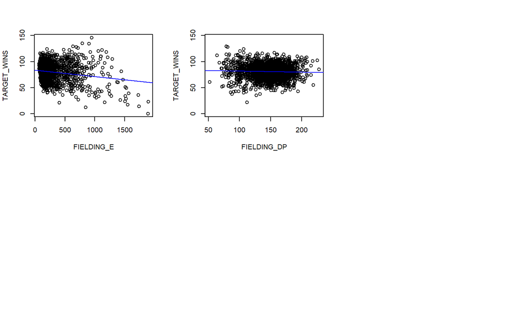

```r
plot(TARGET_WINS ~ FIELDING_E,mtd)
  abline(lm(TARGET_WINS ~ FIELDING_E,data = mtd),col="blue")
plot(TARGET_WINS ~ FIELDING_DP,mtd)
  abline(lm(TARGET_WINS ~ FIELDING_DP,data = mtd),col="blue")
```

This shows very few variables are normally distributed.

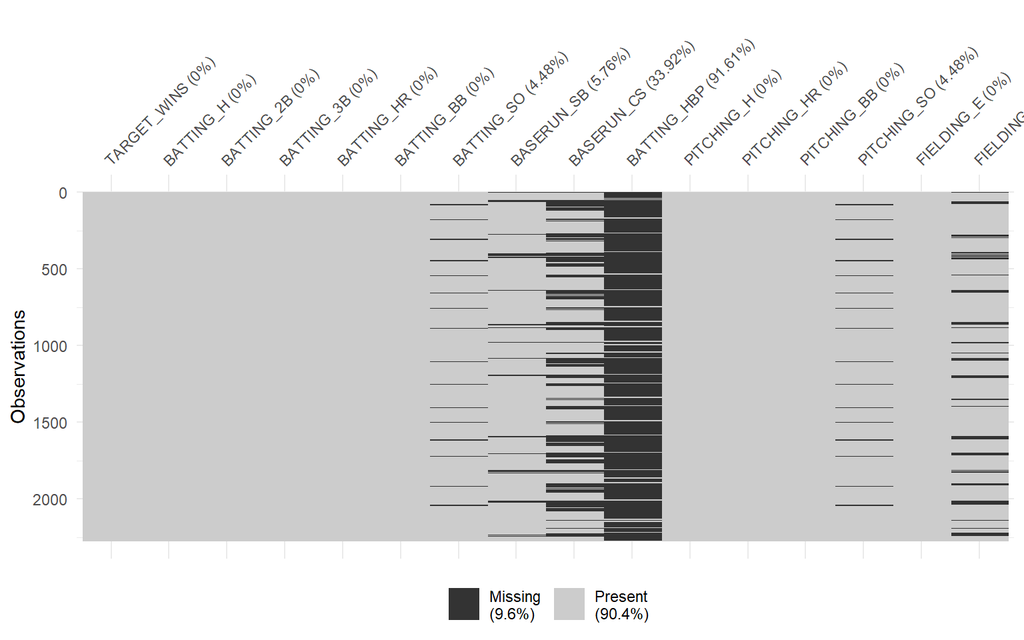

```r
vis_miss(mtd)
```

Here from the plots we can see outliers in PITCHING_H,PITCHING_BB and PITCHING_SO

**Initial Observations**

- Response variable (TARGET_WINS) looks to be normally distributed which means there are good teams, bad teams as well as average teams.
- There are also quite a few variables with missing values. We may need to deal with these in order to have the largest data set possible for modeling.
- A couple variables are bimodal (TEAM_BATTING_HR, TEAM_BATTING_SO, TEAM_PITCHING_HR). This may be a challenge as some of them are missing values and that may be a challenge in filling in missing values.
- Some variables are right skewed (TEAM_BASERUN_CS, TEAM_BASERUN_SB, etc.). This might support the good team theory. It may also introduce non-normally distributed residuals in the model. We shall see.
- Dataset covers a wide time period spanning across multiple “eras” of baseball.

# 4 DATA PREPARATION

Describe how you have transformed the data by changing the original variables or creating new variables. If you did transform the data or create new variables, discuss why you did this. Here are some possible transformations. a. Fix missing values (maybe with a Mean or Median value) b. Create flags to suggest if a variable was missing c. Transform data by putting it into buckets d. Mathematical transforms such as log or square root (or use Box-Cox) e. Combine variables (such as ratios or adding or multiplying) to create new variables

**Fixing Missing/Zero Values** Remove the invalid data and prep it for imputation.

```r
remove_bad_values <- function(df){
  # Change 0's to NA so they too can be imputed
  df <- df %>%
  mutate(BATTING_SO = ifelse(BATTING_SO == 0, NA, BATTING_SO))
  # Remove the high pitching strikeout values
  df[which(df$PITCHING_SO > 5346),"PITCHING_SO"] <- NA
  # Drop the hit by pitcher variable
  df %>%
    select(-BATTING_HBP)
}
mtd <- remove_bad_values(mtd)
med <- remove_bad_values(med)
```

**Imputing the values using KNN**

```r
set.seed(42)
knn <- mtd %>% DMwR::knnImputation()
impute_values <- function(df, knn){
  impute_me <- is.na(df$BATTING_SO)
  df[impute_me,"BATTING_SO"] <- knn[impute_me,"BATTING_SO"]
  impute_me <- is.na(df$BASERUN_SB)
  df[impute_me,"BASERUN_SB"] <- knn[impute_me,"BASERUN_SB"]
  impute_me <- is.na(df$BASERUN_CS)
  df[impute_me,"BASERUN_CS"] <- knn[impute_me,"BASERUN_CS"]
  impute_me <- is.na(df$PITCHING_SO)
  df[impute_me,"PITCHING_SO"] <- knn[impute_me,"PITCHING_SO"]
  impute_me <- is.na(df$FIELDING_DP)
  df[impute_me,"FIELDING_DP"] <- knn[impute_me,"FIELDING_DP"]
  return(df)
}
imputed_mtd_Data <- impute_values(mtd, knn)

# Including batting singles
add_features <- function(df){
  df %>%
    mutate(BATTING_1B = BATTING_H - BATTING_2B - BATTING_3B - BATTING_HR)
}

mtd <- add_features(mtd)
med <- add_features(med)
```

# 5 BUILD MODELS

Using the training data set, build at least three different multiple linear regression models, using different variables (or the same variables with different transformations). Since we have not yet covered automated variable selection methods, you should select the variables manually (unless you previously learned Forward or Stepwise selection, etc.). Since you manually selected a variable for inclusion into the model or exclusion into the model, indicate why this was done.

Discuss the coefficients in the models, do they make sense? For example, if a team hits a lot of Home Runs, it would be reasonably expected that such a team would win more games. However, if the coefficient is negative (suggesting that the team would lose more games), then that needs to be discussed. Are you keeping the model even though it is counter intuitive? Why? The boss needs to know.

```r
set.seed(42)
train_index <- createDataPartition(mtd$TARGET_WINS, p = .7, list = FALSE, times = 1)
moneyball_train <- mtd[train_index,]
moneyball_test <- mtd[-train_index,]
```

## 5.1 Model 1 : Kitchen Sink Model

With all variables to determine the base model provided. This would allow to see which variables are significant in our dataset, and allows to make other models based on that.

```r
model1 <- lm(TARGET_WINS ~., data=moneyball_train)
summary(model1)
```

```
##
## Call:
## lm(formula = TARGET_WINS ~ ., data = moneyball_train)
##
## Residuals:
##      Min       1Q   Median       3Q      Max
## -30.0724  -6.5828  -0.1407   6.4786  28.3847
##
## Coefficients: (1 not defined because of singularities)
##             Estimate Std. Error t value Pr(>|t|)
## (Intercept) 58.53113    7.79100   7.513 1.25e-13 ***
## BATTING_H    0.01653    0.02346   0.704 0.481330
## BATTING_2B  -0.07540    0.01100  -6.854 1.23e-11 ***
## BATTING_3B   0.17325    0.02552   6.789 1.90e-11 ***
## BATTING_HR   0.13176    0.09460   1.393 0.163944
## BATTING_BB   0.02796    0.05440   0.514 0.607397
## BATTING_SO   0.01254    0.02769   0.453 0.650670
## BASERUN_SB   0.03694    0.01026   3.600 0.000334 ***
## BASERUN_CS   0.05115    0.02196   2.329 0.020032 *
## PITCHING_H   0.01747    0.02210   0.791 0.429325
## PITCHING_HR -0.02926    0.09070  -0.323 0.747075
## PITCHING_BB  0.01110    0.05237   0.212 0.832216
## PITCHING_SO -0.03241    0.02645  -1.225 0.220789
## FIELDING_E  -0.16207    0.01230 -13.176  < 2e-16 ***
## FIELDING_DP -0.10625    0.01545  -6.875 1.07e-11 ***
## BATTING_1B        NA         NA      NA       NA
## ---
## Signif. codes:  0 '***' 0.001 '**' 0.01 '*' 0.05 '.' 0.1 ' ' 1
##
## Residual standard error: 9.469 on 1037 degrees of freedom
##   (543 observations deleted due to missingness)
## Multiple R-squared:  0.4421, Adjusted R-squared:  0.4346
## F-statistic:  58.7 on 14 and 1037 DF,  p-value: < 2.2e-16
```

It does a fairly good job predicting, but there are a lot of variables that are not statistically significant.

## 5.2 Model 2 : Simple Model

```r
model2 <- lm(TARGET_WINS ~ BATTING_H  + BATTING_3B  + BATTING_HR + BATTING_BB  + BATTING_SO +
                           BASERUN_SB + PITCHING_SO + PITCHING_H + PITCHING_SO +
                           FIELDING_E + FIELDING_DP, data=moneyball_train)
summary(model2)
```

```
##
## Call:
## lm(formula = TARGET_WINS ~ BATTING_H + BATTING_3B + BATTING_HR +
##     BATTING_BB + BATTING_SO + BASERUN_SB + PITCHING_SO + PITCHING_H +
##     PITCHING_SO + FIELDING_E + FIELDING_DP, data = moneyball_train)
##
## Residuals:
##     Min      1Q  Median      3Q     Max
## -31.633  -7.407   0.103   7.218  29.771
##
## Coefficients:
##              Estimate Std. Error t value Pr(>|t|)
## (Intercept) 73.346701   6.624503  11.072  < 2e-16 ***
## BATTING_H   -0.036127   0.012857  -2.810 0.005032 **
## BATTING_3B   0.201222   0.022342   9.007  < 2e-16 ***
## BATTING_HR   0.114499   0.010869  10.535  < 2e-16 ***
## BATTING_BB   0.032347   0.003796   8.522  < 2e-16 ***
## BATTING_SO   0.048172   0.020693   2.328 0.020072 *
## BASERUN_SB   0.074635   0.006672  11.186  < 2e-16 ***
## PITCHING_SO -0.071270   0.019581  -3.640 0.000284 ***
## PITCHING_H   0.043819   0.011707   3.743 0.000190 ***
## FIELDING_E  -0.111738   0.008436 -13.245  < 2e-16 ***
## FIELDING_DP -0.105429   0.014630  -7.206 9.77e-13 ***
## ---
## Signif. codes:  0 '***' 0.001 '**' 0.01 '*' 0.05 '.' 0.1 ' ' 1
##
## Residual standard error: 10.29 on 1286 degrees of freedom
##   (298 observations deleted due to missingness)
## Multiple R-squared:  0.3949, Adjusted R-squared:  0.3902
## F-statistic: 83.92 on 10 and 1286 DF,  p-value: < 2.2e-16
```

## 5.3 Model 3 : Higher Order Stepwise Regression

```r
model3 <- lm(TARGET_WINS ~ BATTING_1B + BATTING_2B + BATTING_3B + BATTING_HR + BATTING_BB + BATTING_SO +
                           BASERUN_SB + BASERUN_CS +
                           PITCHING_H + PITCHING_HR + PITCHING_BB + PITCHING_SO +
                           FIELDING_E + FIELDING_DP +
                           I(BATTING_1B^2) + I(BATTING_2B^2) + I(BATTING_3B^2) + I(BATTING_HR^2) + I(BATTING_BB^2) + I(BATTING_SO^2) +
                           I(BASERUN_SB^2) + I(BASERUN_CS^2) +
                           I(PITCHING_H^2) + I(PITCHING_HR^2) + I(PITCHING_BB^2) + I(PITCHING_SO^2) +
                           I(FIELDING_E^2) + I(FIELDING_DP^2) +
                           I(BATTING_2B^3) + I(BATTING_3B^3) + I(BATTING_HR^3) + I(BATTING_BB^3) + I(BATTING_SO^3) +
                           I(BASERUN_SB^3) + I(BASERUN_CS^3) +
                           I(PITCHING_H^3) + I(PITCHING_HR^3) + I(PITCHING_BB^3) + I(PITCHING_SO^3) +
                           I(FIELDING_E^3) + I(FIELDING_DP^3) +
                           I(BATTING_1B^3) + I(BATTING_2B^4) + I(BATTING_3B^4) + I(BATTING_HR^4) + I(BATTING_BB^4) + I(BATTING_SO^4) +
                           I(BASERUN_SB^4) + I(BASERUN_CS^4) +
                           I(PITCHING_H^4) + I(PITCHING_HR^4) + I(PITCHING_BB^4) + I(PITCHING_SO^4) +
                           I(FIELDING_E^4) + I(FIELDING_DP^4) + I(BATTING_1B^4), data=moneyball_train)

step_back <- MASS::stepAIC(model3, direction="backward", trace = F)
poly_call <- summary(step_back)$call
step_back <- lm(poly_call[2], moneyball_train)
summary(step_back)
```

```
##
## Call:
## lm(formula = poly_call[2], data = moneyball_train)
##
## Residuals:
##      Min       1Q   Median       3Q      Max
## -29.3740  -6.3034  -0.1952   6.2077  26.1001
##
## Coefficients:
##                    Estimate Std. Error t value Pr(>|t|)
## (Intercept)       3.188e+02  1.044e+02   3.055  0.00231 **
## BATTING_2B        8.256e-01  5.205e-01   1.586  0.11298
## BATTING_BB       -3.382e+00  1.266e+00  -2.672  0.00767 **
## BATTING_SO        4.697e+00  1.527e+00   3.076  0.00215 **
## PITCHING_HR      -3.189e-01  1.537e-01  -2.075  0.03820 *
## PITCHING_BB       2.486e+00  9.366e-01   2.654  0.00808 **
## PITCHING_SO      -4.661e+00  1.444e+00  -3.227  0.00129 **
## I(BATTING_1B^2)  -9.801e-04  3.806e-04  -2.575  0.01016 *
## I(BATTING_2B^2)  -4.315e-03  2.036e-03  -2.119  0.03431 *
## I(BATTING_BB^2)   2.121e-03  8.614e-04   2.463  0.01396 *
## I(BATTING_SO^2)  -3.678e-03  1.485e-03  -2.477  0.01341 *
## I(BASERUN_SB^2)   1.715e-04  3.723e-05   4.607 4.61e-06 ***
## I(PITCHING_H^2)   9.739e-05  2.992e-05   3.255  0.00117 **
## I(PITCHING_HR^2)  3.322e-03  1.587e-03   2.093  0.03658 *
## I(PITCHING_SO^2)  3.624e-03  1.293e-03   2.802  0.00517 **
## I(FIELDING_E^2)  -9.489e-04  1.638e-04  -5.794 9.14e-09 ***
## I(FIELDING_DP^2) -1.756e-03  5.248e-04  -3.346  0.00085 ***
## I(BATTING_2B^3)   6.004e-06  2.623e-06   2.289  0.02227 *
## I(BATTING_3B^3)   6.187e-06  3.269e-06   1.893  0.05867 .
## I(BATTING_BB^3)  -5.279e-07  2.966e-07  -1.780  0.07540 .
## I(BATTING_SO^3)   1.640e-06  8.379e-07   1.957  0.05061 .
## I(BASERUN_CS^3)   1.830e-06  7.946e-07   2.303  0.02145 *
## I(PITCHING_H^3)  -2.172e-08  7.806e-09  -2.782  0.00550 **
## I(PITCHING_HR^3) -1.344e-05  6.971e-06  -1.928  0.05409 .
## I(PITCHING_BB^3) -1.602e-06  6.497e-07  -2.465  0.01385 *
## I(PITCHING_SO^3) -1.612e-06  6.526e-07  -2.470  0.01369 *
## I(FIELDING_E^3)   1.803e-06  5.822e-07   3.096  0.00201 **
## I(FIELDING_DP^3)  6.100e-06  2.188e-06   2.788  0.00540 **
## I(BATTING_1B^3)   1.125e-06  4.713e-07   2.387  0.01716 *
## I(BATTING_SO^4)  -3.008e-10  1.936e-10  -1.553  0.12063
## I(PITCHING_HR^4)  1.703e-08  1.056e-08   1.612  0.10721
## I(PITCHING_BB^4)  8.033e-10  3.398e-10   2.364  0.01826 *
## I(PITCHING_SO^4)  2.908e-10  1.304e-10   2.230  0.02596 *
## I(BATTING_1B^4)  -3.810e-10  1.636e-10  -2.329  0.02003 *
## ---
## Signif. codes:  0 '***' 0.001 '**' 0.01 '*' 0.05 '.' 0.1 ' ' 1
##
## Residual standard error: 9.267 on 1018 degrees of freedom
##   (543 observations deleted due to missingness)
## Multiple R-squared:  0.4755, Adjusted R-squared:  0.4585
## F-statistic: 27.96 on 33 and 1018 DF,  p-value: < 2.2e-16
```

# 6 SELECT MODELS

Decide on the criteria for selecting the best multiple linear regression model. Will you select a model with slightly worse performance if it makes more sense or is more parsimonious? Discuss why you selected your model.

For the multiple linear regression model, will you use a metric such as Adjusted R2, RMSE, etc.? Be sure to explain how you can make inferences from the model, discuss multi-collinearity issues (if any), and discuss other relevant model output. Using the training data set, evaluate the multiple linear regression model based on (a) mean squared error, (b) R2, (c) F-statistic, and (d) residual plots.

Make predictions using the evaluation data set.

### 6.0.1 Model 1 : Kitchen Sink Model

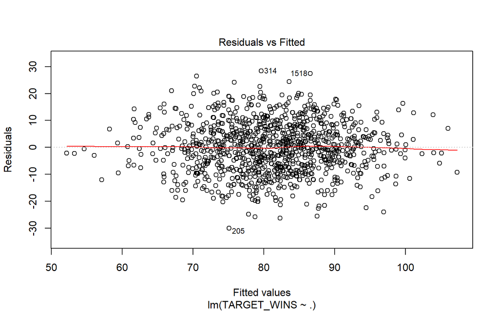

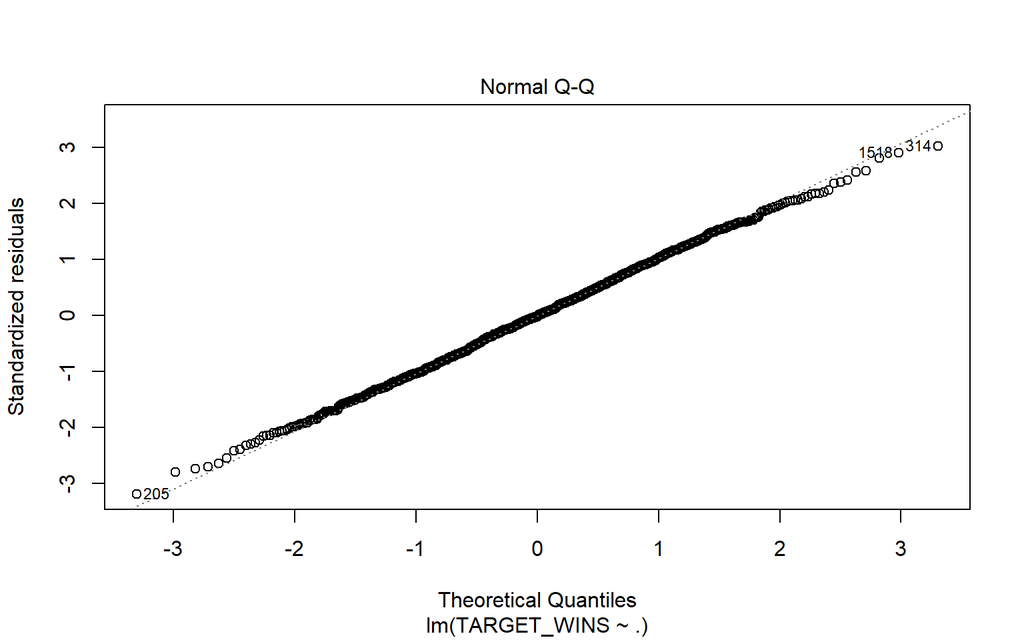

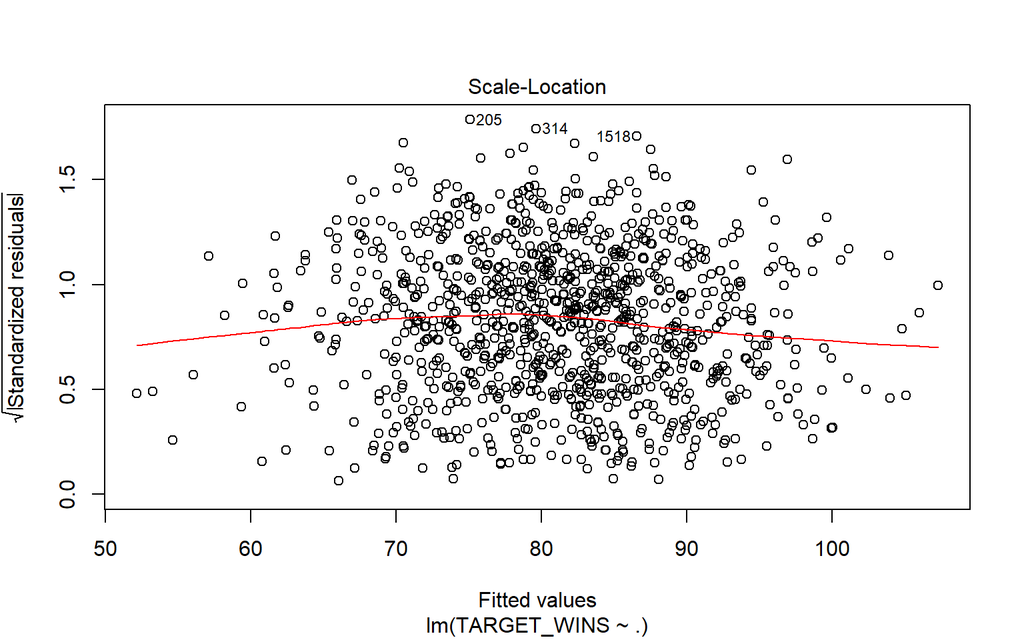

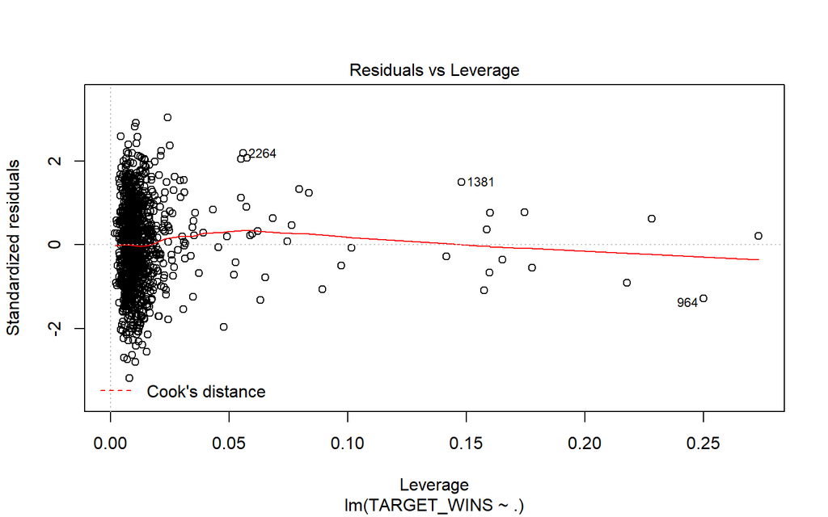

```r
plot(model1)
```

```r
moneyball_test$kitchen_sink <- predict(model1, moneyball_test)
```

[figure not shown]

```r
moneyball_test <- moneyball_test %>%
                    mutate(kitchen_sink_error = TARGET_WINS - kitchen_sink)

ggplot(moneyball_test, aes(kitchen_sink_error)) +
  geom_histogram(bins = 50) +
  annotate("text",x=0,y=10,
           label = paste("RMSE = ",
                         round(sqrt(mean(moneyball_test$kitchen_sink_error^2)),2)
                         ),
           color="white"
           )
```

```r
summary(moneyball_test$kitchen_sink_error)
```

```
##     Min.  1st Qu.   Median     Mean  3rd Qu.     Max.     NA's
## -28.3735  -6.9033  -0.1124  -0.0408   6.4889  27.6495      247
```

### 6.0.2 Model 2 : Simple Model

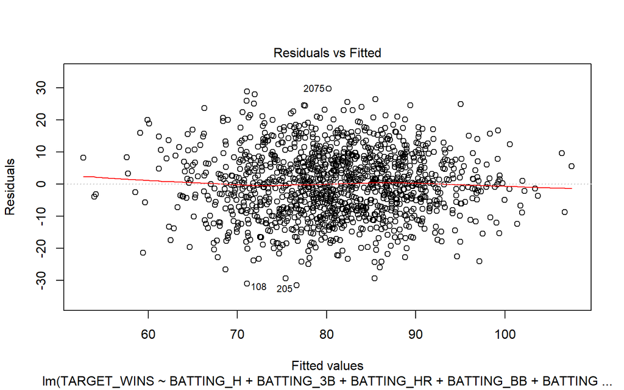

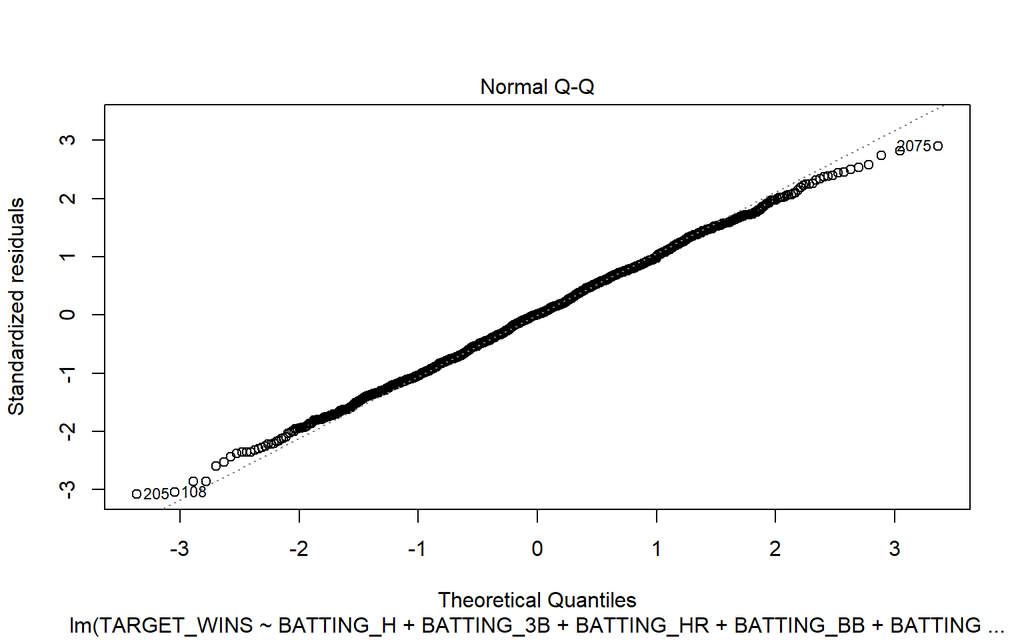

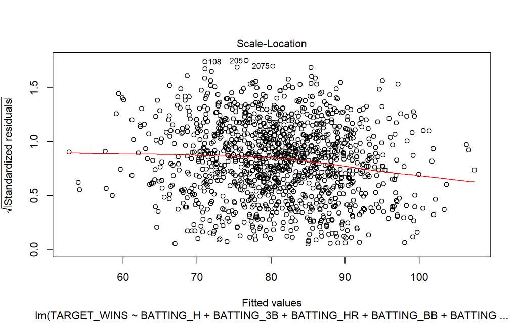

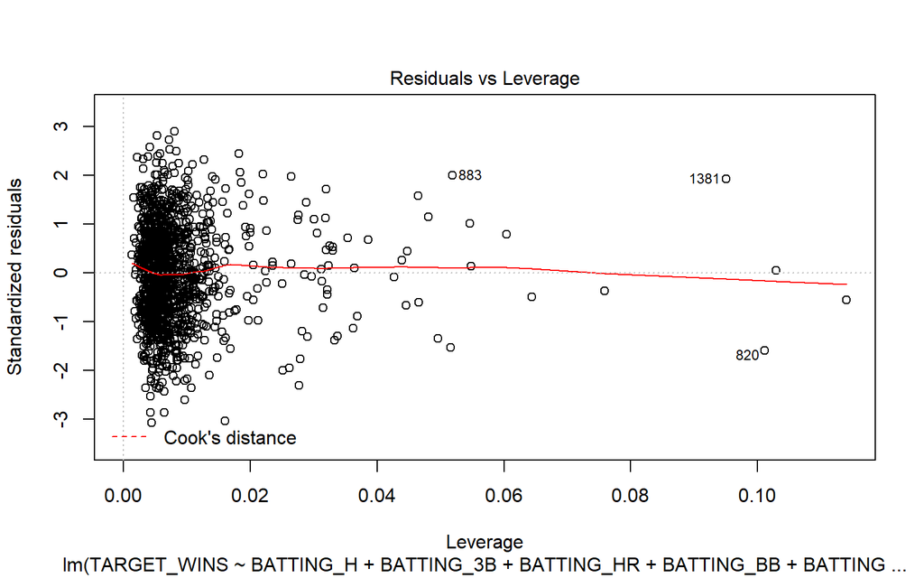

```r
plot(model2)
```

[figure not shown]

```r
moneyball_test$simple <- predict(model2, moneyball_test)
moneyball_test <- moneyball_test %>%
                    mutate(simple_error = TARGET_WINS - simple)

ggplot(moneyball_test, aes(simple_error)) +
  geom_histogram(bins = 50) +
  annotate("text",x=0,y=10,
           label = paste("RMSE = ",
                         round(sqrt(mean(moneyball_test$simple_error^2)),2)
                         ),
           color="white"
           )
```

```r
summary(moneyball_test$simple_error)
```

```
##     Min.  1st Qu.   Median     Mean  3rd Qu.     Max.     NA's
## -27.2876  -7.6292   0.2432  -0.1372   6.5731  29.6379      143
```